# Youth Suicide Deaths in Washington State

### By: Ha My Nguyen

## 1. Introduction

This project is going to explore the Youth Suicide Deaths in Washington State by Gender Age 0-17 Years, from 2008-2012. The json file is being collected from https://catalog.data.gov/dataset/youth-suicide-deaths-in-washington-state-by-gender-age-0-17-years-from-2008-2012.

Firstly , this report will explore the data by columns to get an idea of how the data look like then data will be converted into dictionary for further using purposes. Next, data cleaning will take in progress to get rid of unneccessary data. Afterwards, this report will perform different type of chart to compare the suicide rate by Year, Gender and County.

Finally, conclusion will be made with several recommendations.

## 2. Data Exploration

```python
import json
import matplotlib.pyplot as plt
import matplotlib
import numpy as np
```

```python
file = open("suicide.json")
suicide = json.load(file)
```

```python
columns = []
c_list = suicide["meta"]["view"]["columns"]
for item in c_list:
    columns.append(item["name"])
```

```python
columns
```

```
['sid',
 'id',
 'position',
 'created_at',
 'created_meta',
 'updated_at',
 'updated_meta',
 'meta',
 'County',
 'Female (2012)',
 'Male (2012)',
 'Total (2012)',
 'Female (2011)',
 'Male (2011)',
 'Total (2011)',
 'Female (2010)',
 'Male (2010)',
 'Total (2010)',
 'Female (2009)',
 'Male (2009)',
 'Total (2009)',
 'Female (2008)',
 'Male (2008)',
 'Total (2008)',
 'Female (2008-2012)',
 'Male (2008-2012)',
 'Total (2008-2012)']
```

```python
data_dict = {}
```

```python
# Convert the data into dictionary.
for i in range(len(suicide["data"])):
    data = []
    for j in range(len(suicide["data"][0])):
        data.append(suicide["data"][j][i])
    data_dict[i] = data
```

```python
# Delete the unneccessary columns sid','id','position','created_at','created_meta','updated_at','updated_meta','meta',
for i in range(8):
    del data_dict[i]
```

```python
# Rename the dictionary items.
for i in range(8,27):
    data_dict[columns[i]] = data_dict.pop(i)
```

```python
# Get the new dictionary name list.
name_list = columns[-19:]
```

```python
# Convert the strings of number into integers.
for i in range(1,19):
    for j in range(len(data_dict[name_list[i]])):
        data_dict[name_list[i]][j] = int(data_dict[name_list[i]][j])
```

```python
data_dict
```

[output not shown]

[output cut: 458 more lines]

[output not shown]

Draw a line graph to compare Total number of youth suicide from 2008-2012 by County

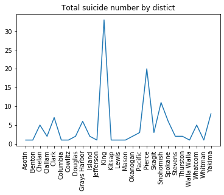

```python
plt.title("Total suicide number by distict")
plt.xticks(rotation = 'vertical')
plt.plot(data_dict['County'],data_dict['Total (2008-2012)'])
```

Draw bar chart to compare the youth suicide between Gender in different County

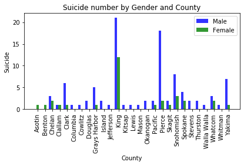

```python
n_groups = len(data_dict['County'])
means_frank = (90, 55, 40, 65)
means_guido = (85, 62, 54, 20)

# create plot
fig, ax = plt.subplots()
index = np.arange(n_groups)
bar_width = 0.35
opacity = 0.8

rects1 = plt.bar(index, data_dict['Male (2008-2012)'], bar_width,
alpha=opacity,
color='b',
label='Male')

rects2 = plt.bar(index + bar_width, data_dict['Female (2008-2012)'], bar_width,
alpha=opacity,
color='g',
label='Female')

plt.xlabel('County')
plt.ylabel('Suicide')
plt.title('Suicide number by Gender and County')
plt.xticks(index + bar_width, data_dict['County'],rotation = 'vertical')
plt.legend()

plt.tight_layout()
plt.show()
```

Draw a pie chart to compare youth suicide by Year

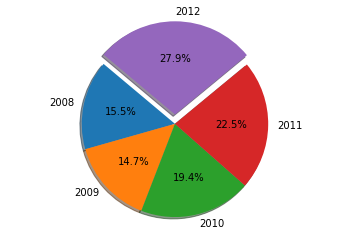

```python
# Data to plot
labels = '2008', '2009', '2010', '2011', '2012'
sizes = [sum(data_dict['Total (2008)']), sum(data_dict['Total (2009)']), sum(data_dict['Total (2010)']), sum(data_dict['Total (2011)']), sum(data_dict['Total (2012)'])]
explode = (0, 0, 0, 0, 0.1)

# Plot
plt.pie(sizes, explode=explode, labels=labels,
autopct='%1.1f%%', shadow=True, startangle=140)

plt.axis('equal')
plt.show()
```

As drawn in the pie chart, the percentage of youth suicide is lowest in 2009 (14.7%) and follows the increasing trend along the years after. It reach the highest ranking in the year 2012 (27.9%).

## 4. Recommendation

The age from 0 to 17 years old is the time that teenager might face a lot of physical issue due to the change in their body, sexual and soul. The high rate of suicide technically gives an alert to all parents and government about lacking talented person in the future. Along with the rapidly development of society, rather than business, parents should spend more time with their children during this important growth up period and so does the government need to take into action of further investigation and creating new project of education strategy which helps teenagers have the right awareness of how important human wellbeing is and also how to deal with changes that challenge their life.